# Module 7 HW

Diana McSpadden (hdm5s)

3/28/2021

# Q1

Draw an example (of your own invention) of a partition of two-dimensional feature space that could result from recursive binary splitting. Your example should contain at least six regions. Draw a decision tree corresponding to this partition. Be sure to label all aspects of your figures, including the regions R1,R2, . . ., the cutpoints t1, t2, . . ., and so forth.

Hint: Your result should look something like Figures 8.1 and 8.2.

[figure not shown]

Question 1

```r
library(MASS)
library(tree)
library(tidyverse)
library(partykit)
library(rattle)
```

```r
library(rpart.plot)
library(RColorBrewer)
library(randomForest)
```

# Q9

This problem involves the OJ data set which is part of the ISLR package.

## (a) Create a training set containing a random sample of 800 observations,…

and a test set containing the remaining observations.

**About OJ Data Set**: The data contains 1070 purchases where the customer either purchased Citrus Hill or Minute Maid Orange Juice. A number of characteristics of the customer and product are recorded.

A data frame with 1070 observations on the following 18 variables.

```r
oj = ISLR::OJ

oj = oj %>% mutate(Purchase = factor(Purchase), SpecialCH = factor(SpecialCH), SpecialMM = factor(SpecialMM), STORE = factor(STORE))

set.seed(1976)

train_oj = sample(1: nrow(oj ), 800, replace = FALSE) # 800 training observations

training_oj = oj[train_oj,]

head(training_oj)
```

```
##     Purchase WeekofPurchase StoreID PriceCH PriceMM DiscCH DiscMM SpecialCH
## 635       CH            241       3    1.79    2.23      0    0.0         0
## 308       MM            263       2    1.86    2.18      0    0.0         0
## 376       CH            258       1    1.76    2.18      0    0.0         0
## 612       CH            233       7    1.75    1.99      0    0.4         1
## 712       MM            263       3    1.99    2.09      0    0.0         0
## 220       CH            272       7    1.86    2.13      0    0.0         0
##     SpecialMM  LoyalCH SalePriceMM SalePriceCH PriceDiff Store7 PctDiscMM
## 635         0 0.850578        2.23        1.79      0.44     No  0.000000
## 308         1 0.217535        2.18        1.86      0.32     No  0.000000
## 376         0 0.320000        2.18        1.76      0.42     No  0.000000
## 612         0 0.204800        1.59        1.75     -0.16    Yes  0.201005
## 712         0 0.000317        2.09        1.99      0.10     No  0.000000
## 220         0 0.989732        2.13        1.86      0.27    Yes  0.000000
##     PctDiscCH ListPriceDiff STORE
## 635         0          0.44     3
## 308         0          0.32     2
## 376         0          0.42     1
## 612         0          0.24     0
## 712         0          0.10     3
## 220         0          0.27     0
```

## (b) Fit a tree to the training data, …

with Purchase as the response and the other variables as predictors. Use the summary() function to produce summary statistics about the tree, and describe the results obtained. What is the training error rate? How many terminal nodes does the tree have?

**Process Q9b:** I am going to use the rpart library for this question because I am interested in learning how to use the library. Below are my notes from reading about the library, and I document how this library differs slightly from the tree exampled from the textbook.

Reference: https://www.gormanalysis.com/blog/decision-trees-in-r-using-rpart/ **minsplit** is “the minimum number of observations that must exist in a node in order for a split to be attempted”

**minbucket** is “the minimum number of observations in any terminal node”.

By default, rpart uses **gini** impurity to select splits when performing classification.

Setting **cp to a negative amount** ensures that the tree will be fully grown.

**cp** corresponds to the lambda in the tuning step.

**rpart and Cross Validation** When rpart grows a tree it performs **10-fold cross validation on the data** by default.

Use printcp() to see the cross validation results.

**xval = 0** makes this not do cross validation. (Later I will do xval = 10 for cross-validation.)

**cp = -1** ensures the tree wuth be fully grown, regardless of improvements to Rsquared with each split. I use this later in Question 9.

```r
set.seed(1976)

#tree.oj = rpart::rpart(Purchase~., data=training_oj, method='class', parms=list(split='information'), control = rpart.control(xval=0, cp=-1))

tree.oj = rpart::rpart(Purchase~., data=training_oj, method='class', parms=list(split='information'), xval=0)
```

```r
summary(tree.oj)
```

```
## Call:
## rpart::rpart(formula = Purchase ~ ., data = training_oj, method = "class",
##     parms = list(split = "information"), xval = 0)
##   n= 800
##
##           CP nsplit rel error
## 1 0.52272727      0 1.0000000
## 2 0.01623377      1 0.4772727
## 3 0.01000000      4 0.4253247
##
## Variable importance
##        LoyalCH          STORE        StoreID      PriceDiff    SalePriceMM
##             59              7              6              5              5
##        PriceMM         DiscMM      PctDiscMM      SpecialMM WeekofPurchase
##              4              3              3              3              3
##        PriceCH         Store7      SpecialCH
##              1              1              1
##
## Node number 1: 800 observations,    complexity param=0.5227273
##   predicted class=CH  expected loss=0.385  P(node) =1
##     class counts:   492   308
##    probabilities: 0.615 0.385
##   left son=2 (493 obs) right son=3 (307 obs)
##   Primary splits:
##       LoyalCH < 0.48285   to the right, improve=156.29130, (0 missing)
##       StoreID < 3.5       to the right, improve= 47.87931, (0 missing)
##       STORE   splits as  LRRRL, improve= 47.87931, (0 missing)
##       Store7  splits as  RL, improve= 24.63450, (0 missing)
##       DiscCH  < 0.255     to the right, improve= 19.45281, (0 missing)
##   Surrogate splits:
##       STORE          splits as  LLRRL, agree=0.671, adj=0.143, (0 split)
##       StoreID        < 3.5       to the right, agree=0.650, adj=0.088, (0 split)
##       PriceMM        < 1.89      to the right, agree=0.629, adj=0.033, (0 split)
##       WeekofPurchase < 228.5     to the right, agree=0.623, adj=0.016, (0 split)
##       PriceCH        < 1.72      to the right, agree=0.618, adj=0.003, (0 split)
##
## Node number 2: 493 observations,    complexity param=0.01623377
##   predicted class=CH  expected loss=0.1501014  P(node) =0.61625
##     class counts:   419    74
##    probabilities: 0.850 0.150
```

[output cut: 59 more lines]

```
##       Store7         splits as  RL, agree=0.845, adj=0.679, (0 split)
##       SpecialMM      splits as  LR, agree=0.741, adj=0.464, (0 split)
##       WeekofPurchase < 238       to the left,  agree=0.707, adj=0.393, (0 split)
##       SpecialCH      splits as  RL, agree=0.707, adj=0.393, (0 split)
##       DiscMM         < 0.57      to the left,  agree=0.690, adj=0.357, (0 split)
##
## Node number 22: 30 observations
##   predicted class=CH  expected loss=0.4  P(node) =0.0375
##     class counts:    18    12
##    probabilities: 0.600 0.400
##
## Node number 23: 28 observations
##   predicted class=MM  expected loss=0.2142857  P(node) =0.035
##     class counts:     6    22
##    probabilities: 0.214 0.786
```

```r
printcp(tree.oj)
```

```
##
## Classification tree:
## rpart::rpart(formula = Purchase ~ ., data = training_oj, method = "class",
##     parms = list(split = "information"), xval = 0)
##
## Variables actually used in tree construction:
## [1] LoyalCH   PriceDiff StoreID
##
## Root node error: 308/800 = 0.385
##
## n= 800
##
##         CP nsplit rel error
## 1 0.522727      0   1.00000
## 2 0.016234      1   0.47727
## 3 0.010000      4   0.42532
```

**Q9b Observations:**

rpart does not produce the fully the grown tree unless the cp parameter is set to -1. I create and examine fuller trees in Q9 part **g**.

The combination of the tree visual (see part d of question 9) and the “importance” table are interesting. The importance table shows “an overall measure of variable importance is the sum of the goodness of split measures for each split for which it was the primary variable…” (rpart documentation https://cran.r-project.org/web/packages/rpart/rpart.pdf)

The importance table says that LoyalCH (brand loyalty to Citrus Hill) is by far the most “important” predictor of whether the sale is Minute Maid or Citrus Hill. This is also clear by the first node of the tree being whether LoyalCH >= 0.48. The CP table describe a root node error of 0.385. This node lowers the error rate to 47.7% of 38.5% == 18% (a significant reduction).

## (c) Type in the name of the tree object …

in order to get a detailed text output. Pick one of the terminal nodes, and interpret the information displayed.

```r
tree.oj
```

```
## n= 800
##
## node), split, n, loss, yval, (yprob)
##       * denotes terminal node
##
##  1) root 800 308 CH (0.61500000 0.38500000)
##    2) LoyalCH>=0.48285 493  74 CH (0.84989858 0.15010142)
##      4) LoyalCH>=0.7039935 293  15 CH (0.94880546 0.05119454) *
##      5) LoyalCH< 0.7039935 200  59 CH (0.70500000 0.29500000)
##       10) PriceDiff>=0.015 142  25 CH (0.82394366 0.17605634) *
##       11) PriceDiff< 0.015 58  24 MM (0.41379310 0.58620690)
##         22) StoreID>=2.5 30  12 CH (0.60000000 0.40000000) *
##         23) StoreID< 2.5 28   6 MM (0.21428571 0.78571429) *
##    3) LoyalCH< 0.48285 307  73 MM (0.23778502 0.76221498) *
```

**Answer Q9c:** The node labeled “3” LoyalCH < 0.48285: 24% of the observations for this node are CH, 76% are MM. Predictions meeting the LoyalCH < 0.48285 criteria will be labeled MM using this tree.

## (d) Create a plot of the tree, …

and interpret the results.

```r
fancyRpartPlot(tree.oj, caption = NULL)
```

[output not shown]

- Leaf 1: LoyalCH >= 0.48, LoyalCH >= 0.7: 95% CH, 5% MM
- Leaf 2: LoyalCH >= 0.48, LoyalCH < 0.7, PriceDiff >= 0.015: 82% CH, 18% MM
- Leaf 3: LoyalCH >= 0.48, LoyalCH < 0.7, PriceDiff < 0.015, StoreID >= 2.5 (i.e. StoreID = 3,4,5,6,…): 60% CH, 40% MM
- Leaf 4: LoyalCH >= 0.48, LoyalCH < 0.7, PriceDiff < 0.015, StoreID < 2.5 (i.e. StoreID = 1 or 2): 21% CH, 79% MM
- Leaf 5: LoyalCH < 0.48: 24% CH, 76% MM

## (e) Predict the response on the test data, …

and produce a confusion matrix comparing the test labels to the predicted test labels. What is the test error rate?

```r
preds_oj = predict(tree.oj, newdata = oj[-train_oj,], type = "class")
preds_oj = data.frame(Pred = factor(preds_oj))
library(caret)
caret::confusionMatrix(preds_oj$Pred, oj[-train_oj,]$Purchase)
```

```
## Confusion Matrix and Statistics
##
##           Reference
## Prediction  CH  MM
##         CH 136  29
##         MM  25  80
##
##                Accuracy : 0.8
##                  95% CI : (0.7472, 0.846)
##     No Information Rate : 0.5963
##     P-Value [Acc > NIR] : 7.627e-13
##
##                   Kappa : 0.5821
##
##  Mcnemar's Test P-Value : 0.6831
##
##             Sensitivity : 0.8447
##             Specificity : 0.7339
##          Pos Pred Value : 0.8242
##          Neg Pred Value : 0.7619
##              Prevalence : 0.5963
##          Detection Rate : 0.5037
##    Detection Prevalence : 0.6111
##       Balanced Accuracy : 0.7893
##
##        'Positive' Class : CH
##
```

**Answer Qe:** The test error rate, or 1 - Accuracy, is **0.20.**

## (f) Apply the cv.tree() function…

to the training set in order to determine the optimal tree size.

```r
tree.oj.10 = rpart::rpart(Purchase~., data=training_oj, method='class', parms=list(split='information'), control = rpart.control(xval=10))
fancyRpartPlot(tree.oj.10, caption = NULL)
```

[output not shown]

**Q9f Observations:** THis is the same tree produced without cross-validation; which concerns me. I did try running the rpart with a control that set cp =-1, which ensures a fully-grown tree, and I got a **much** different result.

## (g) Produce a plot with tree size …

on the x-axis and cross-validated classification error rate on the y-axis.

```r
tree.oj.cv = rpart::rpart(Purchase~., data=training_oj, method='class', parms=list(split='information'), control = rpart.control(xval=10))
tree.oj.cv.cp = printcp(tree.oj.cv)
```

```
##
## Classification tree:
## rpart::rpart(formula = Purchase ~ ., data = training_oj, method = "class",
##     parms = list(split = "information"), control = rpart.control(xval = 10))
##
## Variables actually used in tree construction:
## [1] LoyalCH   PriceDiff StoreID
##
## Root node error: 308/800 = 0.385
##
## n= 800
##
##         CP nsplit rel error  xerror     xstd
## 1 0.522727      0   1.00000 1.00000 0.044685
## 2 0.016234      1   0.47727 0.47727 0.035565
## 3 0.010000      4   0.42532 0.47727 0.035565
```

```r
df.cv.cp = data.frame(tree.oj.cv.cp)
df.cv.cp
```

```
##           CP nsplit rel.error    xerror       xstd
## 1 0.52272727      0 1.0000000 1.0000000 0.04468505
## 2 0.01623377      1 0.4772727 0.4772727 0.03556473
## 3 0.01000000      4 0.4253247 0.4772727 0.03556473
```

**This is the fully grown tree:**

```r
tree.oj.full = rpart::rpart(Purchase~., data=training_oj, method='class', parms=list(split='information'), control = rpart.control(xval=10, cp=-1))
tree.oj.full.cp = printcp(tree.oj.full)
```

```
##
## Classification tree:
## rpart::rpart(formula = Purchase ~ ., data = training_oj, method = "class",
##     parms = list(split = "information"), control = rpart.control(xval = 10,
##         cp = -1))
##
## Variables actually used in tree construction:
##  [1] DiscMM         LoyalCH        PriceCH        PriceDiff      PriceMM
##  [6] SalePriceCH    SalePriceMM    SpecialCH      STORE          StoreID
## [11] WeekofPurchase
##
## Root node error: 308/800 = 0.385
##
## n= 800
##
##           CP nsplit rel error  xerror     xstd
## 1  0.5227273      0   1.00000 1.00000 0.044685
## 2  0.0162338      1   0.47727 0.47727 0.035565
## 3  0.0097403      4   0.42532 0.47078 0.035376
## 4  0.0081169      6   0.40584 0.46104 0.035088
## 5  0.0032468     14   0.33442 0.43831 0.034394
## 6  0.0000000     17   0.32468 0.47078 0.035376
## 7 -1.0000000     46   0.32468 0.47078 0.035376
```

```r
df.cp = data.frame(tree.oj.full.cp)
df.cp
```

```
##             CP nsplit rel.error    xerror       xstd
## 1  0.522727273      0 1.0000000 1.0000000 0.04468505
## 2  0.016233766      1 0.4772727 0.4772727 0.03556473
## 3  0.009740260      4 0.4253247 0.4707792 0.03537602
## 4  0.008116883      6 0.4058442 0.4610390 0.03508823
## 5  0.003246753     14 0.3344156 0.4383117 0.03439395
## 6  0.000000000     17 0.3246753 0.4707792 0.03537602
## 7 -1.000000000     46 0.3246753 0.4707792 0.03537602
```

**Q9g Observations:** I create data frames for both the cross-validation that stops as soon as improvements to R2 are not greater than the CP value, and also with cp = -1 which produced a fully grown tree. For my plot I use the data from the fully grown tree.

The x-axis, **nsplit**, is how many splits are in the tree. The y-axis is the cross-validation error, **xerror**.

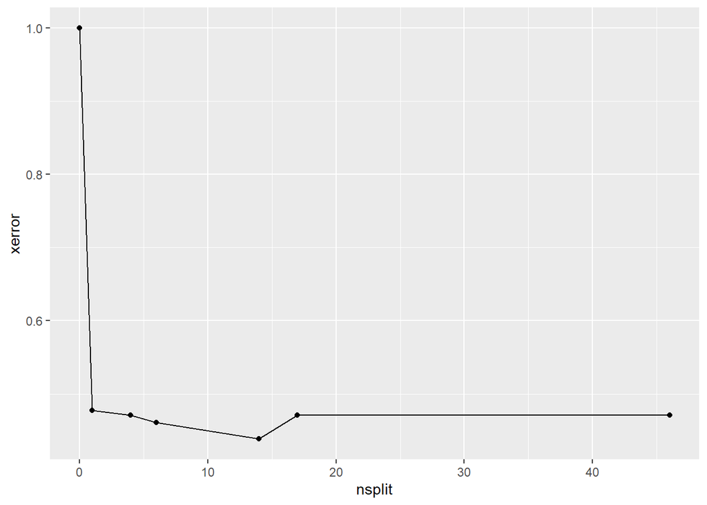

```r
ggplot(data=df.cp, aes(x=nsplit, y=xerror)) + geom_line() + geom_point()
```

## (h) Which tree size…

corresponds to the lowest cross-validated classification error rate?

**Answer Q9h:** The tree with 14 splits is the tree with the lowest cross-validation error rate.

To visualize this tree I set the cp to slightly larger than the cp for that tree in the cp table produced by the fully grown tree.

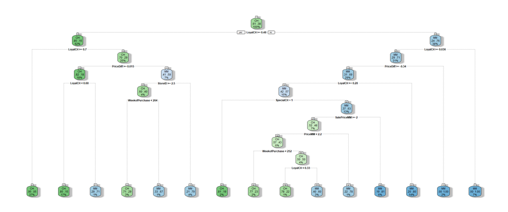

```r
tree.oj.14 = rpart::rpart(Purchase~., data=training_oj, method='class', parms=list(split='information'), control = rpart.control(xval=10, cp=0.0036))

fancyRpartPlot(tree.oj.14, caption = NULL)
```

## (i) Produce a pruned tree …

corresponding to the optimal tree size obtained using cross-validation. If cross-validation does not lead to selection of a pruned tree, then create a pruned tree with five terminal nodes.

```r
fancyRpartPlot(tree.oj.10, caption = NULL)
```

[output not shown]

## (j) Compare the training error rates between the pruned and unpruned trees.

Which is higher?

```r
printcp(tree.oj.full)
```

```
##
## Classification tree:
## rpart::rpart(formula = Purchase ~ ., data = training_oj, method = "class",
##     parms = list(split = "information"), control = rpart.control(xval = 10,
##         cp = -1))
##
## Variables actually used in tree construction:
##  [1] DiscMM         LoyalCH        PriceCH        PriceDiff      PriceMM
##  [6] SalePriceCH    SalePriceMM    SpecialCH      STORE          StoreID
## [11] WeekofPurchase
##
## Root node error: 308/800 = 0.385
##
## n= 800
##
##           CP nsplit rel error  xerror     xstd
## 1  0.5227273      0   1.00000 1.00000 0.044685
## 2  0.0162338      1   0.47727 0.47727 0.035565
## 3  0.0097403      4   0.42532 0.47078 0.035376
## 4  0.0081169      6   0.40584 0.46104 0.035088
## 5  0.0032468     14   0.33442 0.43831 0.034394
## 6  0.0000000     17   0.32468 0.47078 0.035376
## 7 -1.0000000     46   0.32468 0.47078 0.035376
```

**Answer Q9i:** The training error rate was calculated to be **16.4% for the pruned tree** as shown in Q9b.

For the full tree, the root has an error rate of 0.385, then the error decreases as followed using the rel error column from the printcp(…) function:

- 1 split: 0.385 * 0.477 = 0.18
- 4 splits: 0.385 * 0.425 = 0.164
- 6 splits: 0.385 * 0.4 = 0.154
- 14 splits: 0.385 * 0.33 = 0.127
- 17 splits: 0.385 * 0.32 = 0.123
- 46 splits: 0.385 * 0.32 = **0.123**

The training error is smaller in the fully grown tree.

## (k) Compare the test error rates between the pruned and unpruned trees.

Which is higher?

```r
preds_oj_full = predict(tree.oj.full, newdata = oj[-train_oj,], type = "class")
preds_oj_full = data.frame(Pred = factor(preds_oj_full))
caret::confusionMatrix(preds_oj_full$Pred, oj[-train_oj,]$Purchase)
```

```
## Confusion Matrix and Statistics
##
##           Reference
## Prediction  CH  MM
##         CH 143  37
##         MM  18  72
##
##                Accuracy : 0.7963
##                  95% CI : (0.7433, 0.8427)
##     No Information Rate : 0.5963
##     P-Value [Acc > NIR] : 2.055e-12
##
##                   Kappa : 0.5646
##
##  Mcnemar's Test P-Value : 0.01522
##
##             Sensitivity : 0.8882
##             Specificity : 0.6606
##          Pos Pred Value : 0.7944
##          Neg Pred Value : 0.8000
##              Prevalence : 0.5963
##          Detection Rate : 0.5296
##    Detection Prevalence : 0.6667
##       Balanced Accuracy : 0.7744
##
##        'Positive' Class : CH
##
```

**Answer Q9i:**

Accuracy for the pruned tree on test data is 0.8 (error rate 0.2), while accuracy for the fully-grown tree on test data is 0.7963 (error rate 0.2037). While the accuracy isn’t significantly different between the pruned and fully-grown tree, the pruned tree is much simpler, easily explainable, and clearly visualized.